[figure not shown]

Southern Hemisphere Framework

# Australia *&* New Zealand

Sydney. Tasmania. Queenstown. Built on six weeks of living there—not visiting.

Quick Read

## Australia + NZ at a glance

Brady lived in Sydney for six weeks on study abroad. 57 rated spots in Sydney, 18 in Tasmania. Two versions of this trip — Version 1 is Australia only (Sydney + Tasmania), Version 2 adds a trans-Tasman hop to New Zealand. Sydney alone needs a full week to do properly. Tasmania is the underrated second act.

Choose Your Trip

## Two versions. *One decision.*

### Version 1

10–12 days

Sydney + Tasmania. Brady’s full personal knowledge. The focused experience.

### Version 2

14–18 days

+ Queenstown, New Zealand. The full expedition. Research-based—Brady’s next destination.

Brady

Australia is not just a trip. It is a lifestyle reset. The quality of life you experience in Sydney over two weeks is something you spend the next year trying to explain to people who have not been.

Sydney — Personally Validated

## Six weeks in the city. *Not a visit.*

Brady lived in Glebe and the inner west for six weeks. 123 spots in the database, 57 personally rated. Every recommendation is firsthand.

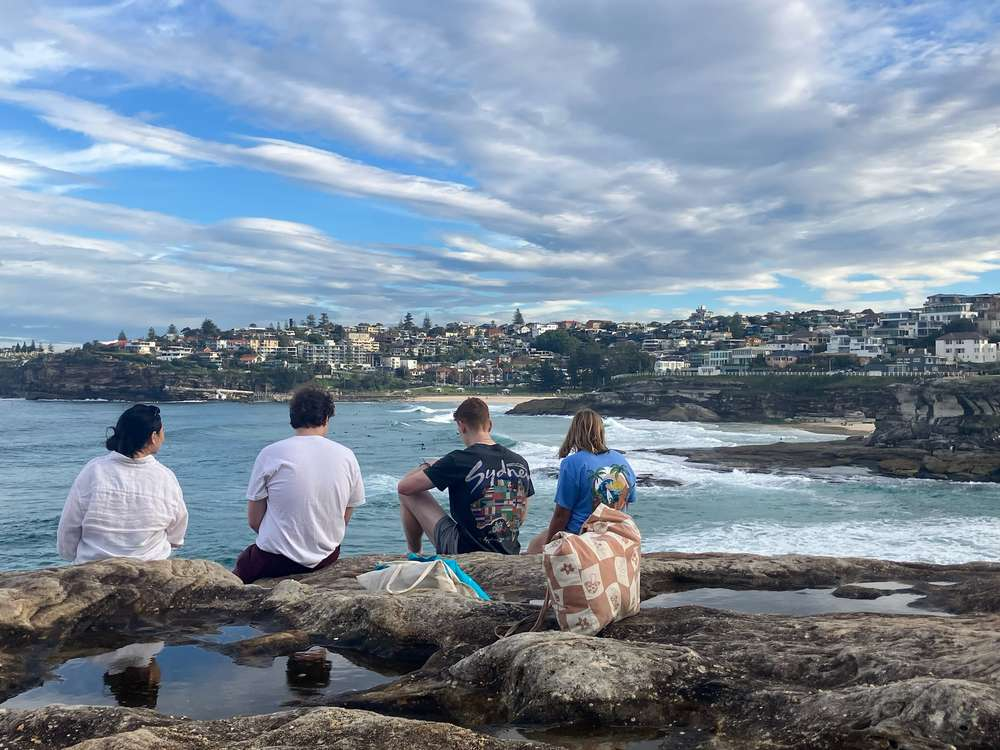

Bondi to Coogee. Go at sunrise.

### Sample Day-by-Day

▾

Day 1

**Arrive + Orient**Check in. Walk to Circular Quay. Opera Bar at golden hour. Early night.

Day 2

**Bondi to Coogee at Sunrise**6km coastal walk. Ocean pools. Afternoon in Surry Hills or Newtown.

Day 3

**Marrickville Brewery Crawl**Saturday only. Philter → Sauce → Grifter → Hawkes → Mixtape. The best day in Sydney.

Day 4

**Manly Ferry + Beach Day**Circular Quay to Manly. Butterboy cookie. 4 Pines Brewery. Use the Opal Sunday cap.

Day 5

**Blue Mountains**Train to Katoomba. Three Sisters, Jamison Valley. Full day commitment. Worth every minute.

Day 6

**Figure 8 Pools or Flex**Tide-dependent. Check the Risk Forecast a week out. Speakeasy circuit at night.

Day 7

**Fly to Tasmania**1h 20m flight. Afternoon in Hobart. Salamanca area for first night.

### The Marrickville Brewery Crawl

▾

[figure not shown]

Philter Brewing — where you start

Brady

Best single day in Sydney. Saturday only. Start at Philter. All walkable.

9.5

Philter Brewing

Start here. Anchor of the crawl. Best of the day.

9.0

Sauce Brewing

West coast IPA and strawberry rhubarb. Exceptional.

8.5

Grifter Brewing

8.0

Hawkes Beer

Red Ripper IPA. Leisure Brewing collab.

7.0

Mixtape Brewing

Double IPA. Chorizo pizza. Solid finish.

### The Speakeasy Circuit

▾

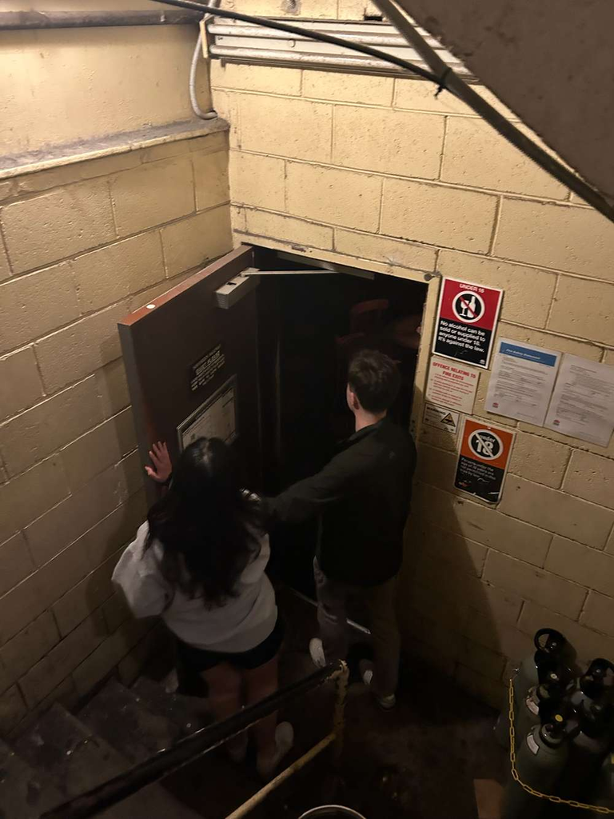

The entrance. You’ll know it when you find it.

Brady

Sydney’s speakeasy scene is genuinely world-class. The Baxter Inn is the anchor.

Maybe Sammy

The Rocks. World’s 50 Best Bars. Italian-inspired cocktails. Go early.

The Baxter Inn

CBD alley entrance. Underground whiskey speakeasy. Enormous whiskey list.

Old Mates Place

CBD rooftop. Rum-focused. Ask at the front bar for the upstairs entrance.

Cantina OK

Barangaroo. Best margarita in Sydney. Very limited seats.

### Best Day Trips

▾

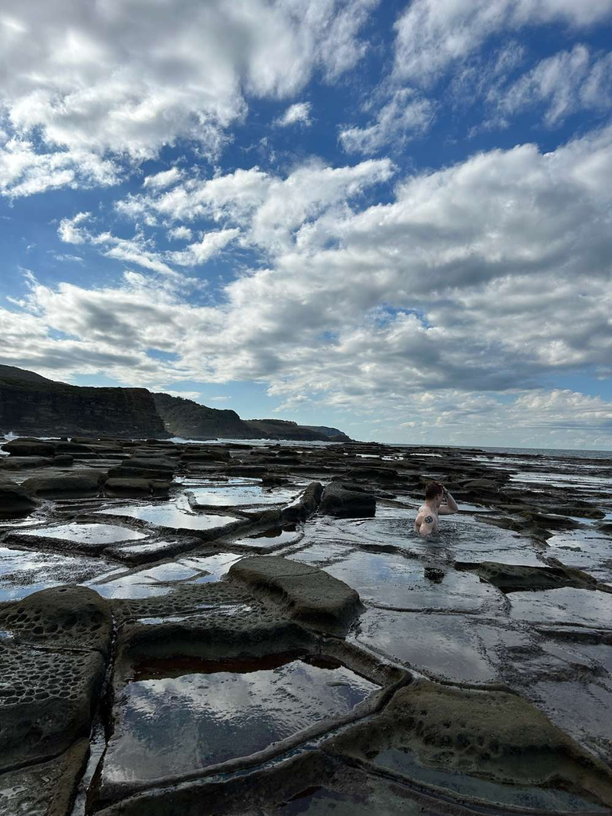

Figure 8 Pools — Brady rates it 11/10

Figure 8 Pools — 11/10

Royal National Park. 6km return. Only at low tide. Plan a week out. Unique on the planet.

Manly Ferry + Day — 9.5/10

Best ferry ride in Sydney. Butterboy cookie. 4 Pines on the way back.

Blue Mountains — 9/10

Katoomba, 1.5 hours. Three Sisters, Jamison Valley. Full day.

Safety — Figure 8 Pools

Check the official Risk Forecast before every visit. Freak waves documented. Do not visit without verifying conditions.

### Where Sydney Actually Eats

▾

Brady

The Marrickville Pork Roll is my number one food pick across all travel. Full stop.

Marrickville Pork Roll

Iconic bánh mì. Take the train specifically for this.

Gelato Messina

Salted caramel and white chocolate. Best gelato in Australia.

Mary’s Burgers

Newtown. Gochujang Chicken Burger.

El Jannah

Lebanese charcoal chicken. Cheap, excellent. Get the garlic sauce.

### Ways to Save in Sydney

▾

Opal Sunday Cap — $9.65 AUD

All-day trains, buses, and ferries. Use it every Sunday.

Bottomless Mimosas — $30

2 hours at Canopy. Brady did this personally.

Wing Deals

20¢ Mondays at Bavarian. 10¢ Wednesdays at El Camino Cantina.

Always Pay in AUD

DCC adds 3–5%. Always select AUD at terminals. No exceptions.

### Vivid Sydney 2026

▾

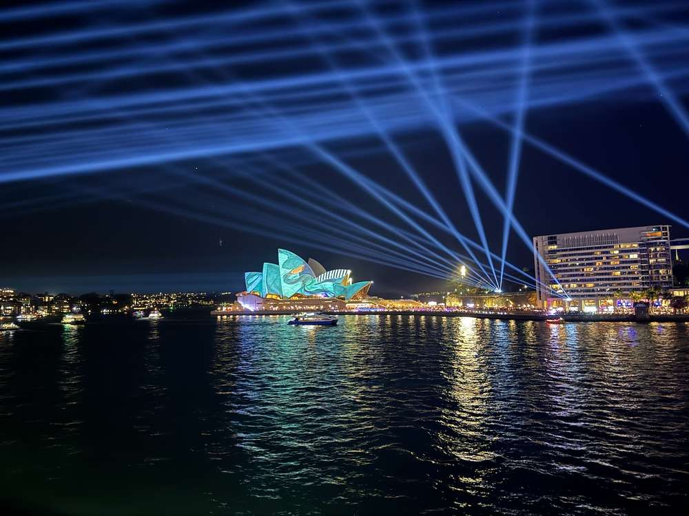

Vivid Sydney — Brady was there.

Brady

I walked to the Opera House during Vivid and watched the harbour drone show from The Rocks. 80% of the program is free. One of the best nights I had in Sydney.

Research-Based

Vivid 2026 runs May 22 to June 13. Tumbalong Nights free concerts. Star-Bound drone show runs 11 nights. Weeknights better than weekends for crowds.

Tasmania — Personally Validated

## Three days is enough. *MONA is the reason.*

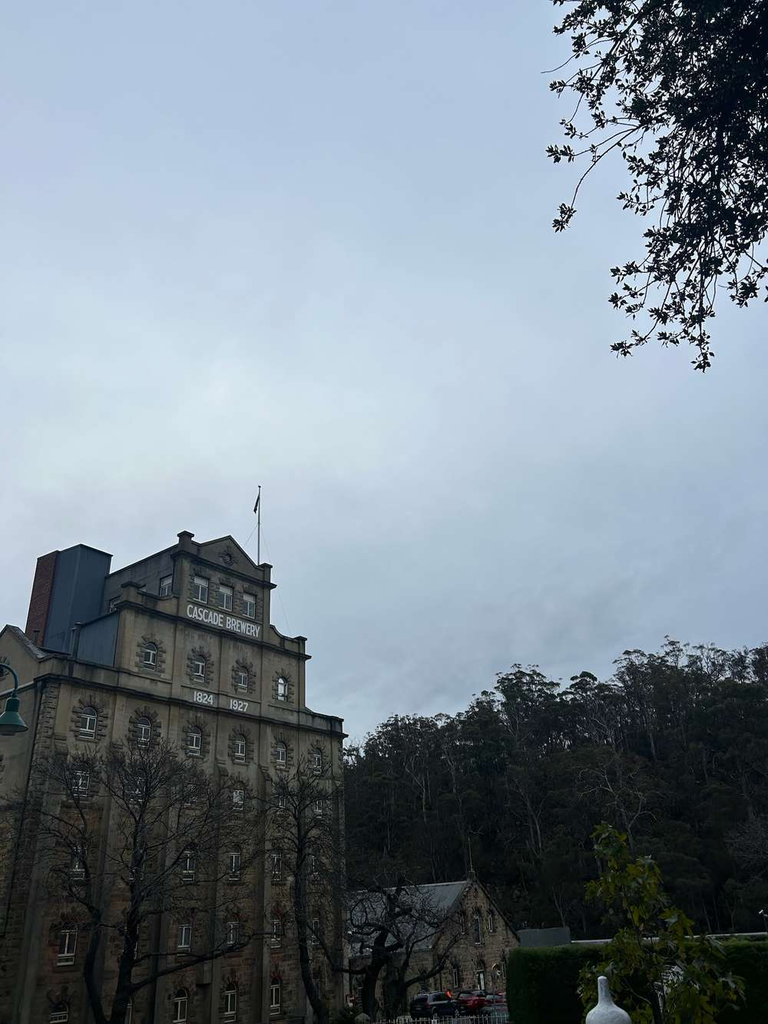

Cascade Brewery — Australia’s oldest. 1824.

Brady

I did four days and covered everything. Three is right for a group. MONA is the anchor—plan Tasmania around it.

### Tasmania Day-by-Day

▾

Day 1

**MONA**Ferry from Sullivans Cove. Half a day minimum. Built underground into sandstone.

Day 2

**Salamanca Market + Mt Wellington**Saturday market if timing works. Summit for views. Cascade Brewery for the wallaby burger.

Day 3

**Battery Point + Fly Out**Sculpture walk. Farm Gate Market if Sunday. Afternoon flight onward.

### Hobart Bar Scene

▾

Pickled Frog

Brady went multiple nights. Hostel bar with a beer garden.

In the Hanging Garden

One of Hobart’s best bars. Beautifully designed.

Hope and Anchor

One of Australia’s oldest pubs. Hot buttered rum.

Research-Based

All public transport in Tasmania is free March 30 to June 30, 2026.

Crossing the Tasman

## New Zealand

Queenstown. Single hub. Maximum intensity. Research-based throughout.

Queenstown — Research-Based

## The vertical *dimension.*

Research-Based

Brady has not been to New Zealand. This section is entirely research-informed. It is next on his bucket list.

Australia is horizontal. New Zealand is vertical—alpine, intense, compressed. After two weeks in Australia, New Zealand resets the threshold.

### Queenstown Day-by-Day

▾

Day 1

**Arrive + Settle**SYD to ZQN direct. Pak’nSave. Fergburger—call ahead to skip the queue.

Day 2

**Nevis Bungy — 134m**8.5 seconds of freefall. $395 NZD pp. The signature moment. Book in advance.

Day 3

**Shotover Jet**$179 NZD pp. Canyon access. 15+ spins. Altitude Brewing after.

Day 4

**Milford Sound Fly-Cruise-Fly**$450–650 NZD pp. Scenic flight over the Southern Alps. Do not take the bus.

Day 5

**Ben Lomond Hike**Free. 6–8 hours. Lake Wakatipu and Alps views. The right recovery day.

### Queenstown Nightlife

▾

Cowboys

Mechanical bull. Rowdy atmosphere. Essential.

The Bunker

Restaurant that becomes a cocktail bar after 11pm.

Winnie’s

Pizza restaurant. Retractable roof. Becomes a nightclub.

### Ways to Save in NZ

▾

Pak’nSave

11–17% cheaper than competitors. Stock up on arrival.

AJ Hackett Combos

10–20% off multiple activities. Visit i-SITE in person for group rates.

NZD Advantage

Trades 5–10% below AUD. Use Wise or Revolut for zero FX fees.

When to Go

## Three windows. *One winner.*

|  | Summer (Dec–Feb) | Vivid (May–Jun) | Shoulder (Mar–Apr) |
| --- | --- | --- | --- |
| Beach | Peak | Cooler, still viable | Good in March |
| Accommodation | +45% | Standard | Lowest |
| Crowds | Peak | Moderate | Low |
| Verdict | Beach & NYE | Festival anchor | Best value |

**Shoulder—March to April—wins for most groups.** Best value, lowest crowds, free Tasmania transport, NZ autumn sweet spot.

Honest Flag — NYE

The Opera House forecourt on NYE requires entering by 3pm and waiting 8–9 hours in a non-alcoholic zone. The actual NYE for a group is a harbour cruise ($549+ pp) or rooftop party. Know this before booking around December 31.

What First-Timers Get Wrong

## Five mistakes that cost real money or real experience

### 1. Underestimating the distances

Sydney to Melbourne is a 9-hour drive. Sydney to Tasmania requires a flight. Australia is the size of the continental US. Do not plan this like a European trip where you hop between cities in two hours.

### 2. Only doing Bondi

Bondi is fine. The Bondi to Coogee coastal walk is great. But Sydney has dozens of beaches — Manly, Bronte, Tamarama, Shelly Beach. Spending every beach day at Bondi is like only going to Times Square in New York.

### 3. Skipping Tasmania

Most first-timers treat Tasmania as optional. It is the best part of the trip for anyone who likes nature, hiking, or food. Hobart alone has a world-class food scene. MONA is unlike any museum you have been to.

### 4. Not budgeting for food and drink

Sydney is expensive. A pint runs $12-15 AUD. A decent dinner is $40-60 AUD per person. Plan for this or the budget blows out by day three.

### 5. Flying through on a stopover

Sydney is not a 3-day city. Six weeks was not enough. Give it at least 7 days, ideally 10 with day trips. The harbour, the beaches, the food scene, the nightlife — it takes time to understand why this city works.

Cost Model

## What this *actually costs.*

|  | Summer | Vivid | Shoulder |
| --- | --- | --- | --- |
| Flights (ORD, RT) | $1,200–1,800 | $1,100–1,600 | $1,100–1,500 |
| Accommodation/day | $150–250 | $120–200 | $120–200 |
| Food & Drink/day | $80–150 | $70–130 | $70–130 |
| V1 Total (10–12d) | $3,500–5,600 | $3,000–5,000 | $2,800–4,800 |
| V2 Total (14–18d) | $5,600–8,400 | $5,000–7,500 | $4,800–7,200 |

All AUD. V2 includes trans-Tasman flights and NZ costs.

Getting There

## The journey is *real.*

No direct Midwest flight. ORD/DTW to LAX/SFO/DFW, then SYD. 20–23 hours. Air Canada from ~$1,144 RT.

Research-Based

Tokyo via ANA or JAL is the strongest stopover. Maximum cultural contrast. Both airlines offer structured stopover programs.

The Lads Travel Co.

dangelobraden43@gmail.com